# Introdução ao ggplot2 - Visualização de Dados

# Introdução ao ggplot2

## Visão Geral

Nesta aula, vamos abordar o `ggplot2`, um dos pacotes mais populares para visualização de dados em R. O `ggplot2` é baseado no conceito de *Gramática dos Gráficos*, uma abordagem que facilita a criação, personalização e compreensão de gráficos.

## Pacotes para Visualização em R

Existem vários pacotes disponíveis para visualização de dados no R, cada um com suas características e casos de uso específicos:

1. **Graphics**:
   - Contém funções gráficas primitivas e é amplamente utilizado para plotagens básicas.
   - Permite criar gráficos a partir de funções de alto e baixo nível.
   - Exemplo: `plot()`, `hist()`, `boxplot()`.
2. **Lattice**:
   - Oferece plotagem multi-painel, ideal para comparações de várias variáveis.
   - Incluído na instalação básica do R, mas deve ser carregado manualmente.
   - Exemplo: `xyplot()`, `bwplot()`.
3. **ggplot2**:
   - Baseado na *Grammar of Graphics*, fornece uma maneira estruturada e extensível de criar gráficos.
   - Permite construir gráficos complexos de forma incremental e intuitiva.
   - Exemplo: `ggplot()`, `geom_point()`, `geom_bar()`.
4. **Pacotes Interativos**:
   - Existem pacotes como `plotly` e `shiny` que permitem criar gráficos interativos.

## Introdução ao `ggplot2`

O `ggplot2` é baseado na gramática dos gráficos, que pode ser entendida como a construção de gráficos por meio de camadas. Cada camada adiciona um componente diferente ao gráfico, resultando em visualizações complexas e informativas.

### Estrutura Básica do ggplot2

**Referência Visual do ggplot2**:

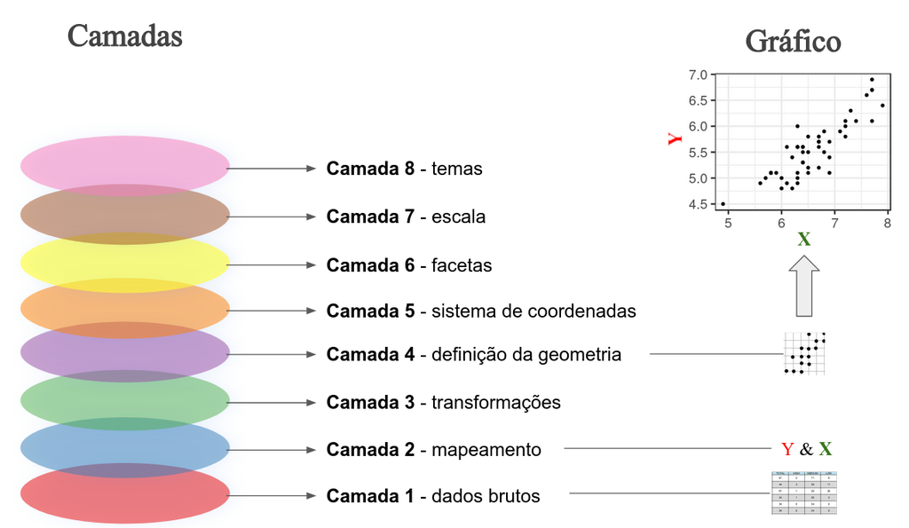

1. **Dados**:
   - O primeiro passo na criação de qualquer gráfico é definir os dados que serão visualizados.
2. **Mapeamento Estético**:
   - Define como os dados serão mapeados para atributos visuais, como posição, cor, tamanho, etc.
3. **Geometria**:
   - Define a forma geométrica usada para representar os dados, como pontos, barras, linhas, etc.
4. **Facetas**:
   - Permite dividir os gráficos em múltiplos painéis com base em uma ou mais variáveis.
5. **Estatísticas**:
   - Aplica cálculos estatísticos sobre os dados antes de plotá-los, como linhas de tendência ou intervalos de confiança.
6. **Sistema de Coordenadas**:
   - Define o sistema de coordenadas, como cartesiano, polar, etc.
7. **Tema**:
   - Personaliza a aparência do gráfico, como fontes, cores, espessura das linhas, etc.

### Exemplo Básico com ggplot2

Vamos começar criando um gráfico simples usando o `ggplot2`.

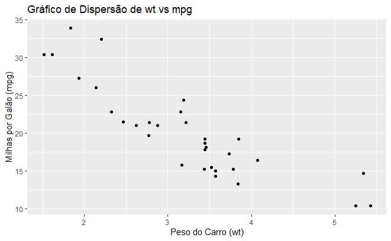

```r
library(ggplot2)

# Usando a base de dados mtcars para um exemplo
data(mtcars)

# Criando um gráfico de dispersão básico
ggplot(mtcars, aes(x = wt, y = mpg)) +
  geom_point() +
  labs(title = "Gráfico de Dispersão de wt vs mpg",
       x = "Peso do Carro (wt)",
       y = "Milhas por Galão (mpg)")
```

## Camadas do ggplot2

### 1. Dados

Os dados são o ponto de partida para qualquer gráfico. No exemplo acima, estamos usando o `mtcars`, uma base de dados embutida no R.

### 2. Mapeamento Estético (aes)

O mapeamento estético determina como os dados são representados visualmente. No exemplo, estamos mapeando `wt` (peso) no eixo X e `mpg` (milhas por galão) no eixo Y.

### 3. Geometria

A geometria define a forma como os dados são visualizados. Usamos `geom_point()` para criar um gráfico de dispersão, onde cada ponto representa uma observação.

### 4. Facetas

Facetas são úteis para dividir o gráfico em subgráficos baseados em valores de uma variável.

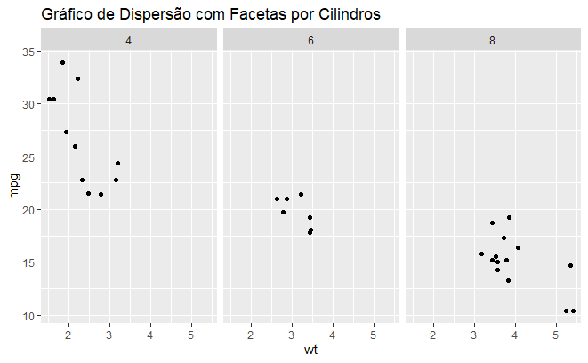

```r
ggplot(mtcars, aes(x = wt, y = mpg)) +
  geom_point() +
  facet_wrap(~cyl) +
  labs(title = "Gráfico de Dispersão com Facetas por Cilindros")
```

### 5. Estatísticas

O ggplot2 permite adicionar camadas estatísticas, como linhas de tendência.

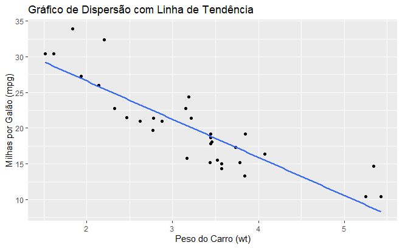

```r
ggplot(mtcars, aes(x = wt, y = mpg)) +
  geom_point() +
  geom_smooth(method = "lm", se = FALSE) +
  labs(title = "Gráfico de Dispersão com Linha de Tendência",
       x = "Peso do Carro (wt)",
       y = "Milhas por Galão (mpg)")
```

### 6. Sistema de Coordenadas

A maioria dos gráficos usa coordenadas cartesianas, mas o ggplot2 permite usar outros sistemas, como coordenadas polares para gráficos de pizza.

### 7. Tema

O tema permite personalizar o visual do gráfico.

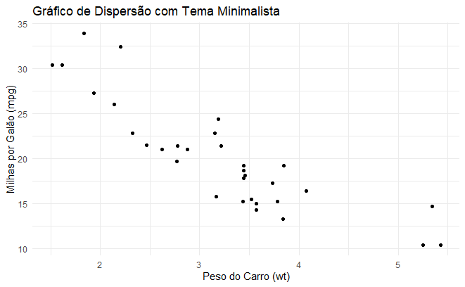

```r
ggplot(mtcars, aes(x = wt, y = mpg)) +
  geom_point() +
  theme_minimal() +
  labs(title = "Gráfico de Dispersão com Tema Minimalista",
       x = "Peso do Carro (wt)",
       y = "Milhas por Galão (mpg)")
```

## Conclusão

Nesta aula, introduzimos os conceitos básicos do `ggplot2` e como ele se encaixa no ecossistema de visualização de dados no R. Compreender a gramática dos gráficos é fundamental para criar visualizações eficazes e informativas. Nas próximas aulas, vamos explorar gráficos mais complexos e personalizações avançadas.